# Data Analytics - Práctica final

Daniel Moreno, Alessandro Bonifaccio y Raúl García

Diseñado por: Ester Bernadó

# 1 Introducción

El documento es el resultado del trabajo de un equipo formado por tres integrantes. En él, se muestra el código y las valoraciones realizadas sobre las preguntas proporcionadas. Para realizar dicho documento, se ha considerado más oportuno tratar cada ejercicio como una unidad independiente. Facilitando su corrección y ejecución individual. A continuación se describen que requisitos son necesarios y las funciones creadas para facilitar el desarrollo individual de cada ejercicio.

## 1.1 Requisitos

### 1.1.1 Librería “knitr”

Librería necesaria para poder generar el documento final de la práctica. Se trata de una librería que tiene como propósito generar reports de manera dinámica en R.

```r
library("knitr")
```

### 1.1.2 Librería “dplyr”

Librería necesaria para facilitar la manipulación de datos. Proporciona más funcionalidades de manipulación de datos que el lenguaje de base.

```r
library("dplyr")
```

### 1.1.3 Librería “lubridate”

Librería necesaria para facilitar la manipulación de fechas. Proporciona más funcionalidades de manipulación de fechas que el lenguaje de base.

```r
library("lubridate")
```

### 1.1.4 Librería “ggplot2”

Librería necesaria para mejorar la visualización de los resultados obtenidos. Proporciona mejoras en la creación y visualización de diagramas.

```r
library("ggplot2")
```

### 1.1.5 Funciones

Para realizar dicho documento, se ha considerado más oportuno tratar cada ejercicio como una unidad independiente. Facilitando su corrección y ejecución individual. Por ese motivo, se ha creado una série de funciones de aspectos que se repeten en varios ejercicios.

```r
GetTrackinData = function() {
  data = read.csv("tracking.csv", sep = ",", na.strings = "NA")
  colnames(data)[4] = "SessionLenght"
  colnames(data)[5] = "MoneySpent"
  return(data)
}

GetUsersData = function() {
  data = read.csv("users.csv", sep = ",", na.strings = "NA")
  return(data)
}
```

Además, se ha creado unas funciones extras para una utilidad muy concreta.

```r
GetUniqueUsersOfMonth = function(monthNumericIdentificator, dataStructure) {
  if(monthNumericIdentificator < 1 || monthNumericIdentificator > 12) {
        return(NULL)
  }
  monthDataFrame = dataStructure[month(as.POSIXlt(trackingData$Date, format="%d/%m/%Y")) == monthNumericIdentificator,]
  return (monthDataFrame)
}

RetentionOfTrackingData = function(DS, daysRetention){
  resultRetention = daysRetention
  index = 1

  for (day in daysRetention) {
    #DataFrame con user, dia instalacion y dia a comprovar.
    data_installs = data.frame(UserID=DS[which(DS$Action == "Install"),]$UserID, DateInstall=DS[which(DS$Action == "Install"),]$Date, DateRetention=rep("", nrow(DS[which(DS$Action == "Install"),])), stringsAsFactors=FALSE)
    data_installs[,'DateRetention'] = as_date(as.character(data_installs$DateInstall)) + day

    #DataFrame con user y dia de sesion
    data_sessions = data.frame(UserID=DS[which(DS$Action == "Session"),]$UserID, DateSession=DS[which(DS$Action == "Session"),]$Date)

    #DataFrame con user con instalacion, dia a comprovar y dia de sesion. Tantos registros de usuario por sesiones que existen.
    data_result = merge(data_installs, data_sessions, all.x=TRUE)

    #Calculos
      retention_users = 0
      for (user in unique(data_result$UserID)){

        if(is.element(unique(as.character(data_result[which(data_result$UserID == user),]$DateRetention)),as.character(data_result[which(data_result$UserID == user),]$DateSession))){

            retention_users = retention_users + 1
        }

      }
    resultRetention[index] = retention_users/length(unique(as.character(data_result$UserID)))
    index = index + 1

  }

  return(resultRetention)
}
```

# 2 Resumen general

En este documento se realizan una série de cálculos de métricas y se realizan análisis sobre unos datos concretos. Éstos son un conjunto de datos obtenidos después de haberse realizado un seguimiento de acciones de cada usuario en un videojuego.

Por lo tanto, se puede observar dos ficheros con datos del “tracking” y con la base de usuarios del juego con datos sobre ellos.

Así pues, a continuación se describen y responden a una série de preguntas que ayudarán a entender mejor los datos que se manejan.

## 2.1 ¿Cuánto tiempo dura el período de seguimiento?

```r
  trackingData = GetTrackinData();
  daysOfTracking = length(unique(trackingData$Date))
```

El seguimiento dura un total de **120 días**.

## 2.2 ¿Cuántos usuarios diferentes han instalado el juego?

```r
  trackingData = GetTrackinData();
  usersInstalledTheGame = unique(trackingData$UserID[trackingData$Action == "Install"])
  usersInstalledGameAmount = length(usersInstalledTheGame)
```

El juego ha sido instalado por **5345 usuarios** diferentes.

## 2.3 ¿Cuántos usuarios diferentes han jugado durante el período de seguimiento?

```r
  trackingData = GetTrackinData();
  usersPlayedGame = unique(trackingData$UserID[trackingData$Action == "Session"])
  usersPlayedGameAmount = length(usersPlayedGame)
```

Durante el período de seguimiento han jugado **5245 usuarios** diferentes. Se observa que ha disminuido respecto los usuarios que tienen el juego intalado.

## 2.4 ¿Cuántos usuarios diferentes han desinstalado el juego?

```r
  trackingData = GetTrackinData();
  usersUninstalledGame = unique(trackingData$UserID[trackingData$Action == "Uninstall"])
  usersUninstalledGameAmount = length(usersUninstalledGame)
```

Se observan **1574 usuarios** que han desinstalado el juego.

## 2.5 ¿Cuál es el promedio del número de sesiones jugadas por los usuarios durante el período de seguimiento?

```r
  trackingData = GetTrackinData();
  temp = trackingData[which(trackingData$Action == "Session"),]
  userSessionFreq = data.frame(table(temp$UserID))
  averageNofSessions = mean(userSessionFreq$Freq)
```

La media de número de sesiones realizadas por los usuarios ha sido de **8.28 sesiones**. Sobre este valor, se ha de tener en cuenta que hay usuarios que aún habiendo instalado el juego, no han jugado.

# 3 Demografía de los usuarios

## 3.1 ¿Cuál es la distribución de los usuarios que participan en el juego, en términos de sexo y edad?

Si observamos el término de sexo:

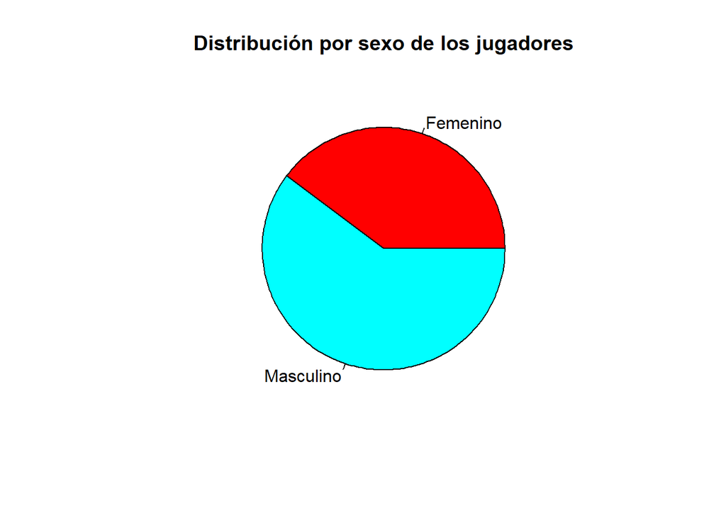

```r
  usersData = GetUsersData()
  temp = table(usersData$sex)
  pie(temp,
      main = "Distribución por sexo de los jugadores",
      labels = c("Femenino", "Masculino"),
      col = rainbow(length(temp))
      )
```

Se aprecia una clara diferencia entre el número de jugadores masculinos (**3221**) y el número de jugadoras femeninas (**2124**).

Respecto al término de edad:

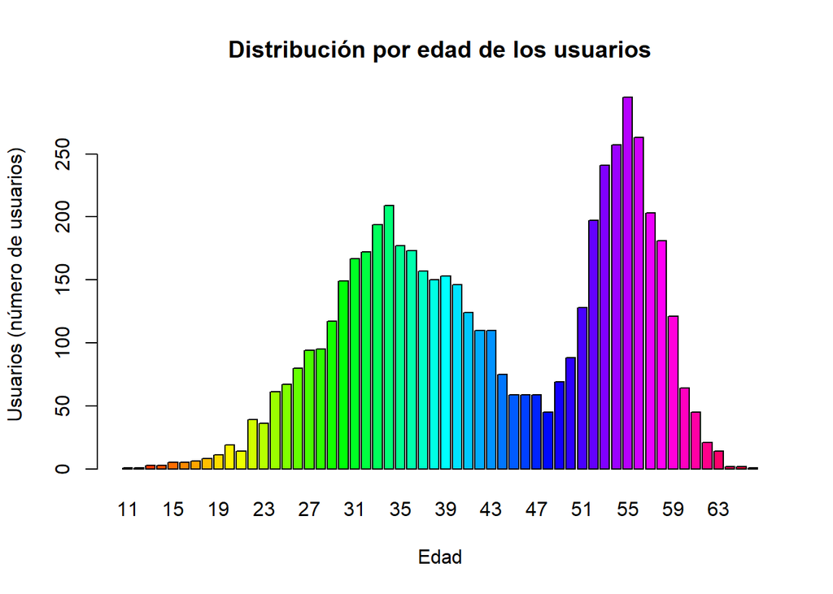

```r
  usersData = GetUsersData()
  barplot(table(usersData$age),
          main = "Distribución por edad de los usuarios",
          col = rainbow(length(table(usersData$age))),
          ylab = "Usuarios (número de usuarios)",
          xlab = "Edad"
          )
```

Se observa una distribución estraña respecto la edad. Parece que el juego es atractivo para dos segementos de edad diferentes. Se aprecia que los segmentos son de los rangos de edad de los 30 a los 40 y de los 50 a los 60.

## 3.2 ¿Cuál es la distribución de edad según el sexo de los jugadores?

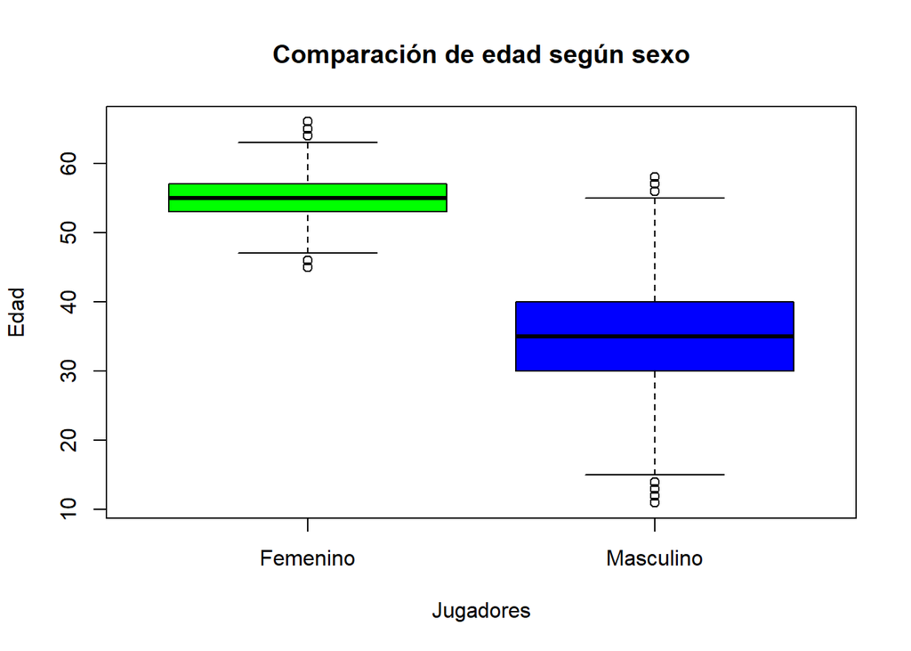

```r
  usersData = GetUsersData()
  femaleSegment = usersData[usersData$sex == "F",]
  maleSegment = usersData[usersData$sex == "M",]
  boxplot(femaleSegment$age, maleSegment$age,
          main = "Comparación de edad según sexo",
          names = c("Femenino", "Masculino"),
          col = c("Green","Blue"),
          ylab = "Edad",
          xlab = "Jugadores"
          )
```

También, es curioso que los jugadores (masculinos) de más edad no jueguen tanto como los jugadores del sexo femenino de esa misma edad. Este hecho puede darse por varios motivos siendo uno de éstos la menor esperanza de vida o la posibilidad de que no existan productos de entretenimiento adecuados para el sexo masculino de dicha edad.

Al observarse la gráfica final, se puede entender realmente el porque existía una distribución de edad estraña.

# 4 Métricas de la población de jugadores

## 4.1 Instalaciones al día

### 4.1.1 ¿Cuántas instalaciones hay por día?

```r
  trackingData = GetTrackinData();
  temp = trackingData[trackingData$Action == "Install",]
  installationsPerDay = temp %>% group_by(Date) %>% summarise(Installs = length(Action))
  installsAverage = mean(installationsPerDay$Installs)
```

Al día se observa una media de **44.54** instalaciones.

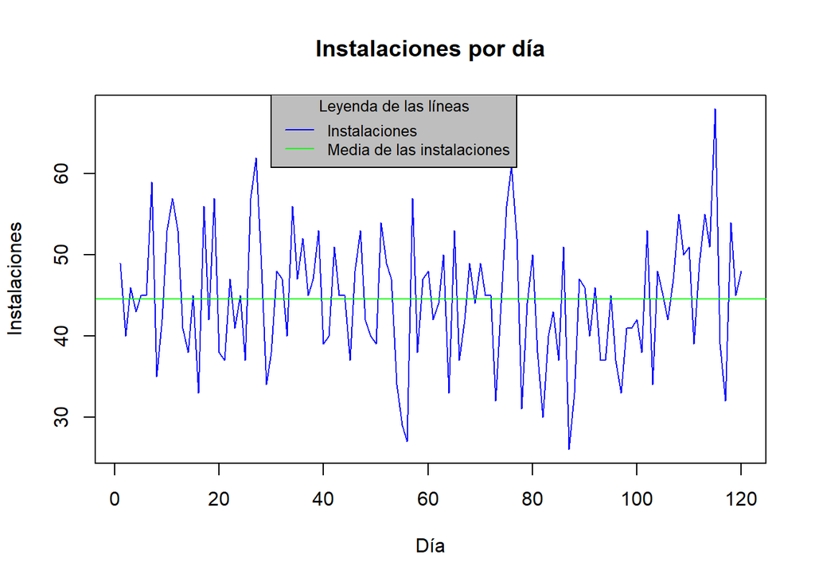

```r
  plot(installationsPerDay$Installs,
       main = "Instalaciones por día",
       ylab = "Instalaciones",
       xlab = "Día",
       type = "l",
       col = "blue"
       )
  abline(h = installsAverage, col = "green")
  legend(x = 30, y = 70,
         legend = c("Instalaciones","Media de las instalaciones"),
         bg = "grey",
         col=c("blue", "green"),
         lty=1:1,
         cex=0.8,
         title = "Leyenda de las líneas")
```

En el gráfico se detallan caídas de número de instalaciones después de períodos con un buen número de instalaciones. Éste hecho, puede ser debido a actividades externas y factores que se desconocen en el estudio.

Si se compara con el número de desinstalaciones al día, se puede obtener información más detallada. Así como poder observar si tiene crecimiento real o no.

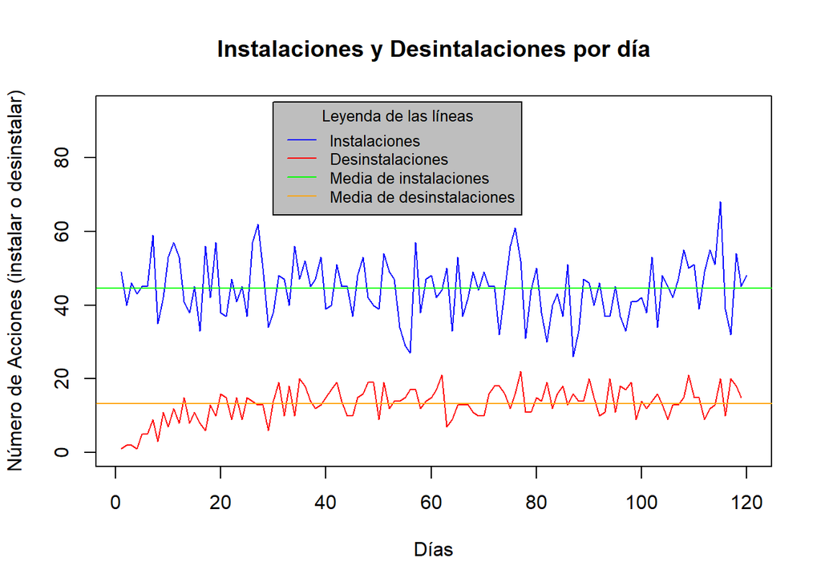

```r
  trackingData = GetTrackinData();

  temp = trackingData[trackingData$Action == "Uninstall",]
  unInstallationsPerDay = temp %>% group_by(Date) %>% summarise(Uninstalls = length(Action))
  uninstallsAverage = mean(unInstallationsPerDay$Uninstalls)

  temp = trackingData[trackingData$Action == "Install",]
  installationsPerDay = temp %>% group_by(Date) %>% summarise(Installs = length(Action))
  installsAverage = mean(installationsPerDay$Installs)

  plot(x = installationsPerDay$Installs,
       main = "Instalaciones y Desintalaciones por día",
       ylab = "Número de Acciones (instalar o desinstalar)",
       xlab = "Días",
       type = "l",
       col = c("blue","red"),
       ylim = c(0,max(installationsPerDay$Installs)+25)
       )
  lines(unInstallationsPerDay$Uninstalls,
        type = "l",
        col = "red"
        )
  abline(h = installsAverage, col = "green")
  abline(h = uninstallsAverage, col = "orange")
  legend(x = 30, y = 95,
         legend = c("Instalaciones","Desinstalaciones", "Media de instalaciones","Media de desinstalaciones"),
         bg = "grey",
         col=c("blue", "red", "green", "orange"),
         lty=1:1,
         cex=0.8,
         title = "Leyenda de las líneas")
```

La media de desintalaciones de la muestra (**13.23**) es inferior a la media de instalaciones (**44.54**). Por lo tanto, se puede deducir que está en crecimiento de usuarios.

## 4.2 DAU

### 4.2.1 ¿Cuánto es el DAU?

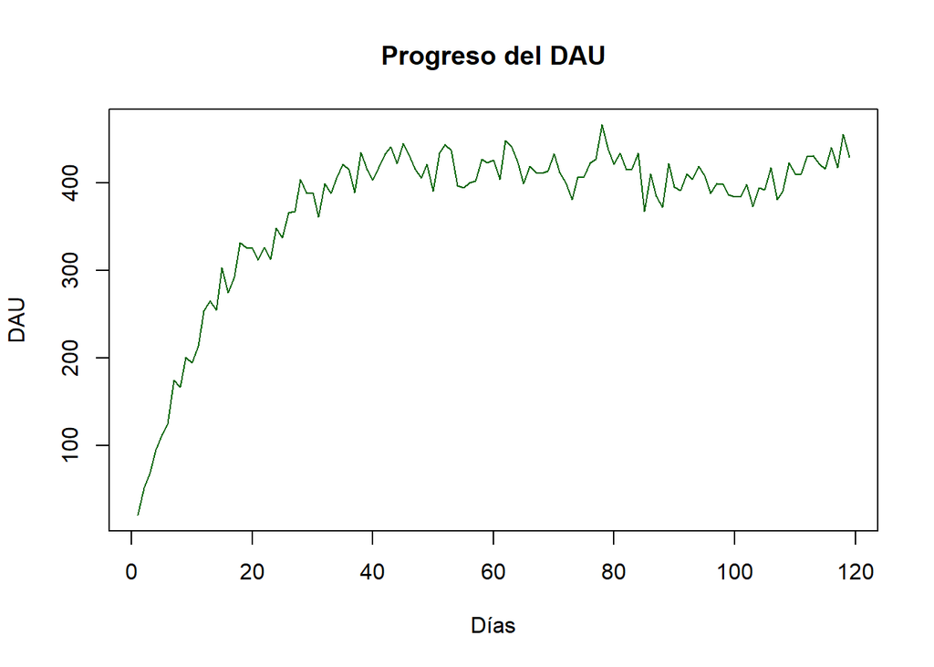

```r
  trackingData = GetTrackinData();

  dtemp = as.Date(trackingData$Date)
  trackingData$Date = NULL;
  trackingData$Date = dtemp;

  trackingDataOnlySesions = trackingData[trackingData$Action == "Session",]

  sesionsPerDay = as.numeric(table(trackingDataOnlySesions$Date))

  sesionsPerDayWithMonth = as.data.frame(sesionsPerDay)
  sesionsPerDayWithMonth$Month = month(as.POSIXlt(unique( trackingDataOnlySesions$Date), format="%d/%m/%Y"))

  plot(sesionsPerDay,
     type = "l",
     xlab = "Días",
     ylab = "DAU",
     main = "Progreso del DAU",
     col = "dark green")
```

Poco después del primer mes, se observa una estabilización de los usuarios activos al día. Puede deberse a diversos motivos entre los cuales se pueden encontrar primeramente un mayor número de usuarios o una mayor retención (especulación). Por lo general, es un crecimiento positivo aunque acaba estancándose alrededor de los 400 a partir del primer mes.

Para comprovar la valoración realizada sobre si el progreso del DAU aumenta debido a un número mayor de usuarios, se muestra a continuación una gráfica con dichos datos.

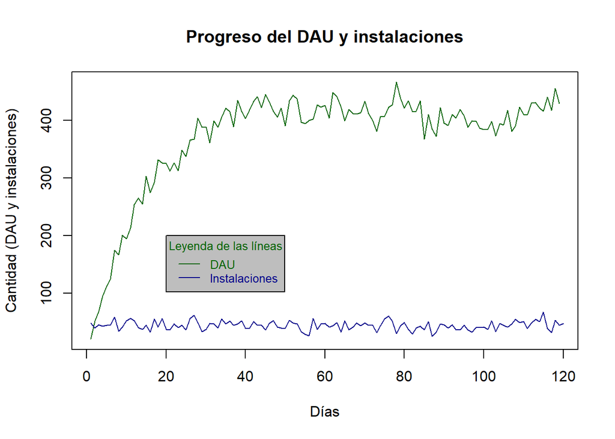

```r
  plot(sesionsPerDay,type = "l",
     xlab = "Días",
     ylab = "Cantidad (DAU y instalaciones)",
     col = "dark green",
     main = "Progreso del DAU y instalaciones")
  lines(installationsPerDay, col= "dark blue" )
  legend (x = 20, y = 200,
        legend = c ("DAU" , "Instalaciones"),
        bg = "grey",
        col = c("dark green", "dark blue"),
        text.col = c("dark green","dark blue"),
        lty=1:1,
        cex=0.8,
        title = "Leyenda de las líneas")
```

Como se puede esperar, el ritmo de instalaciones durante el período de análisis se mantiene estable con pequeños picos. Debido a las instalaciones que se realizan cada día, se observa que el DAU crece debido a los nuevos jugadores. Pero gracias al gráfico se extrae que los jugadores iniciales juegan al juego durante varios días. Permitiendo ver el progreso del DAU de este modo.

## 4.3 MAUU

### 4.3.1 ¿Cuánto es el MAUU?

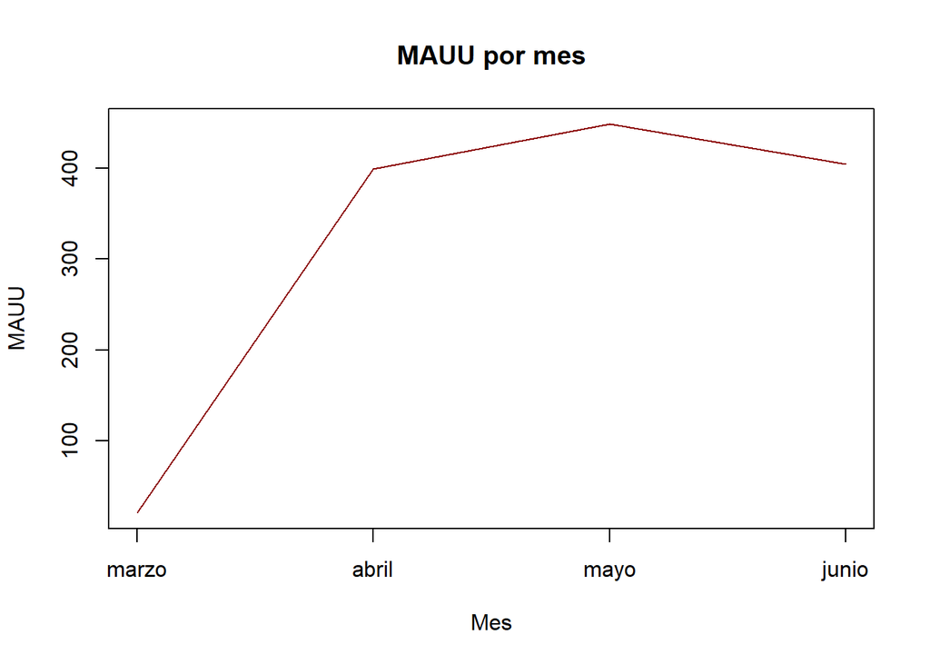

```r
  #trackingData = GetTrackinData()

  monthsOfAnalisis = unique(month(as.POSIXlt(trackingData$Date, format="%d/%m/%Y")))
  trackingData$Month = month(as.POSIXlt(trackingData$Date, format="%d/%m/%Y"))
  monthsOfAnalisisName = unique(months(trackingData$Date))

  maus = rep(1,length(monthsOfAnalisis))
  iterationIndex = 0
  # Iteramos por cada uno de los meses del analisis
  for(mth in monthsOfAnalisis) {
    iterationIndex = iterationIndex + 1
    monthDataFrame = GetUniqueUsersOfMonth(mth,trackingData)
    monthDataFrameOnlySesions = monthDataFrame[monthDataFrame$Action == "Session",]
    # cojemos de el data frame del mes la cantidad de entradas
    activeUsersOfMonth = as.numeric(table(monthDataFrameOnlySesions$Date)  )
    maus[iterationIndex] = activeUsersOfMonth
  }

  plot (maus,
      type = "l",
      xlab = "Mes",
      ylab = "MAUU",
      xaxt="n",
      col = "dark red",
      main = "MAUU por mes")
  axis(side = 1,
       at = c(1,2,3,4),
       labels = monthsOfAnalisisName)
```

En la primera fase del despliegue del producto el MAUU parece ser pequeño debido a que la población de jugadores diarios es aún limitada. En los siguientes meses se percibe un incremento importante ya que la población ya esta establecida.

## 4.4 Ratio DAU/MAUU

### 4.4.1 ¿Cuánto es el ratio DAU/MAUU?

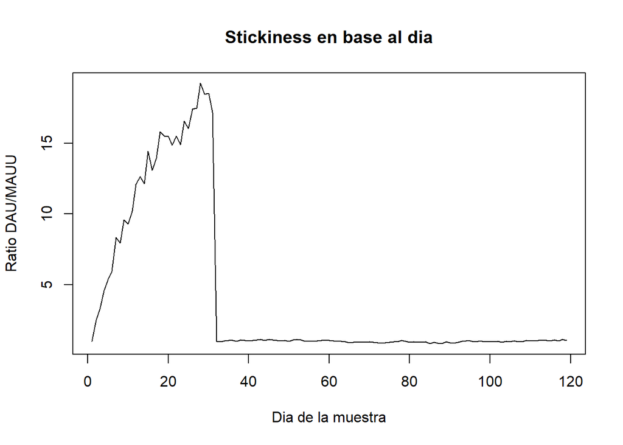

```r
  # Primero debemos saber el DAU --> Ya lo sabemos
  # Y despues conocer el MAUU del mes --> Ya lo tenemos

  #maus                # el mauu de cada mes
  #sesionsPerDayWithMonth       # BASICAMENTE EL DAU DE CADA DIA junto con el mes del cual sale
  #monthsOfAnalisis

  # separate the sesions per each month
  sesionsOfFirstMonth = sesionsPerDayWithMonth[sesionsPerDayWithMonth$Month == monthsOfAnalisis[1],]
  sesionsSecondMonth = sesionsPerDayWithMonth[sesionsPerDayWithMonth$Month == monthsOfAnalisis[2],]
  sesionsThirdMonth = sesionsPerDayWithMonth[sesionsPerDayWithMonth$Month == monthsOfAnalisis[3],]
  sesionsForthMonth = sesionsPerDayWithMonth[sesionsPerDayWithMonth$Month == monthsOfAnalisis[4],]

  # Get for each day the relatio between the sesions / MAUU of the month of the day
  # first month sesions

  dauMauuFirstMonth = sesionsOfFirstMonth$sesionsPerDay / maus[1]
  dauMauuSecondMonth = sesionsSecondMonth$sesionsPerDay / maus[2]
  dauMauuThirdMonth = sesionsThirdMonth$sesionsPerDay / maus[3]
  dauMauuForthMonth = sesionsForthMonth$sesionsPerDay / maus[4]

  dauMauuAglomerated = c(dauMauuFirstMonth,dauMauuSecondMonth, dauMauuThirdMonth, dauMauuForthMonth)

  plot(dauMauuAglomerated,
       main = "Stickiness en base al dia",
       xlab = "Dia de la muestra",
       ylab = "Ratio DAU/MAUU",
       type = "l")
```

```r
  # Interpretacion A
  averageDauMaus = rep(-1,length(monthsOfAnalisis))
  averageDauMaus[1] = mean(dauMauuAglomerated[1])
  averageDauMaus[2] = mean(dauMauuAglomerated[2])
  averageDauMaus[3] = mean(dauMauuAglomerated[3])
  averageDauMaus[4] = mean(dauMauuAglomerated[4])

  averageDauMaus
```

```
## [1] 1.000000 2.476190 3.238095 4.571429
```

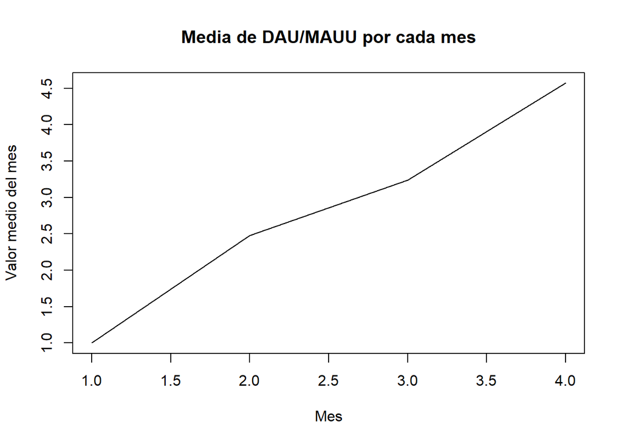

```r
  plot(averageDauMaus,
       main = "Media de DAU/MAUU por cada mes",
       xlab = "Mes",
       ylab = "Valor medio del mes",
       color = "blue",
       type = "l"
       )
```

```r
  # Interpretacion B (media de los dau de un mes partido el mauu de este)
  averageDaus = rep(-1,length(monthsOfAnalisis))
  averageDaus[1] = mean(sesionsOfFirstMonth$sesionsPerDay)
  averageDaus[2] = mean(sesionsSecondMonth$sesionsPerDay)
  averageDaus[3] = mean(sesionsThirdMonth$sesionsPerDay)
  averageDaus[4] = mean(sesionsForthMonth$sesionsPerDay)

  averageDauMauPerMonth = averageDaus / maus
  averageDauMauPerMonth
```

```
## [1] 12.2365591  1.0426065  0.9238911  1.0081591
```

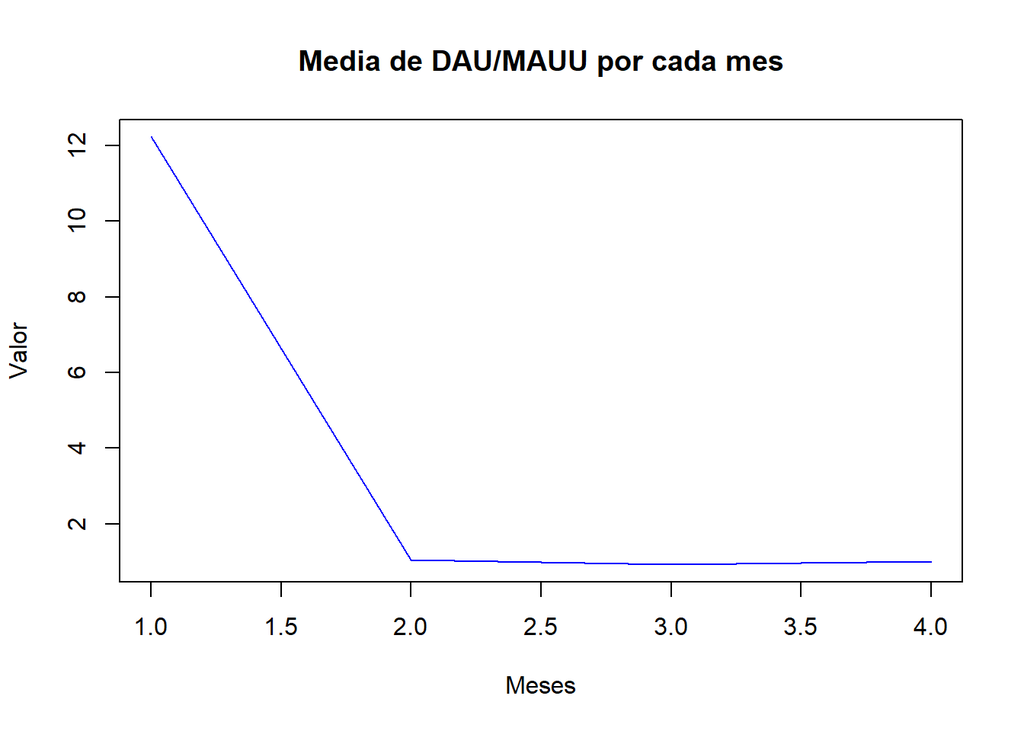

```r
  plot(averageDauMauPerMonth,
       xlab = "Meses",
       ylab = "Valor",
       type ="l",
       main = "Media de DAU/MAUU por cada mes",
       col = "blue")
```

# 5 Métricas de Gameplay

## 5.1 Número de sesiones por jugador

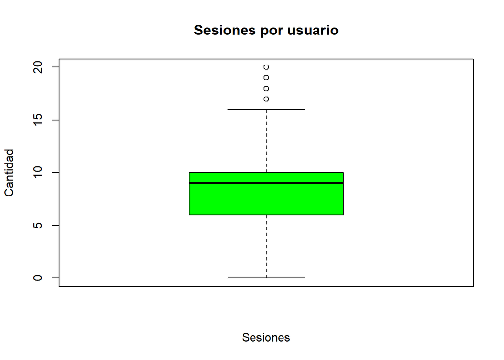

```r
  trackingData = GetTrackinData()
  temp = trackingData[which(trackingData$Action == "Session"),]
  userSessionFreq = data.frame(table(temp$UserID))
  averageNofSessions = mean(userSessionFreq$Freq)

  boxplot(userSessionFreq$Freq,
          main = "Sesiones por usuario",
          names = c("Sesiones"),
          col = c("Green"),
          ylab = "Cantidad",
          xlab = "Sesiones"
          )
```

El número de sesiones de media por el total de usuarios es de **8.28 sesiones**.

## 5.2 Tiempo de juego

### 5.2.1 ¿Cuánto es la media de tiempo destinada por los usuarios en sus sesiones de juego?

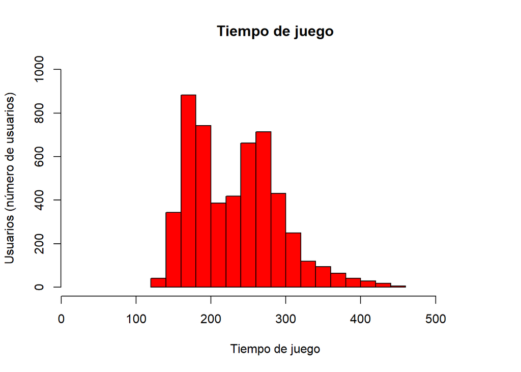

```r
  trackingData = GetTrackinData()
  temp = trackingData[which(trackingData$Action == "Session"),]
  userSessionsAverage = data.frame(summarise(group_by(temp,UserID), TimeSession = mean(SessionLenght)))
  userSessionsAverageSD = data.frame(summarise(group_by(temp,UserID), TimeSession = sd(SessionLenght)))
  AvgTimeSpent = mean(userSessionsAverage$TimeSession)
  AvgStandarDeviation = mean(userSessionsAverageSD$TimeSession)

  hist(userSessionsAverage$TimeSession,
          main = "Tiempo de juego",
          col = rainbow(length(table(userSessionsAverage$TimeSession))),
          ylab = "Usuarios (número de usuarios)",
          xlab = "Tiempo de juego",
          xlim = c(min(userSessionsAverage$TimeSession)-100,max(userSessionsAverage$TimeSession)+100),
          ylim = c(0,1000)
          )
```

## 5.4 Retención

```r
Retention = RetentionOfTrackingData(GetTrackinData(), c(1,7,14,30))
#Retention = c(1,7,14,30)
```

Al calcular la retención del juego con los datos de la muestra, se obtinen las siguientes retenciones en diferentes días.

Retención día 1: **0.60**, retención día 7: **0.37**, retención día 14: **0.21** y la retención día 30: **0.06**.

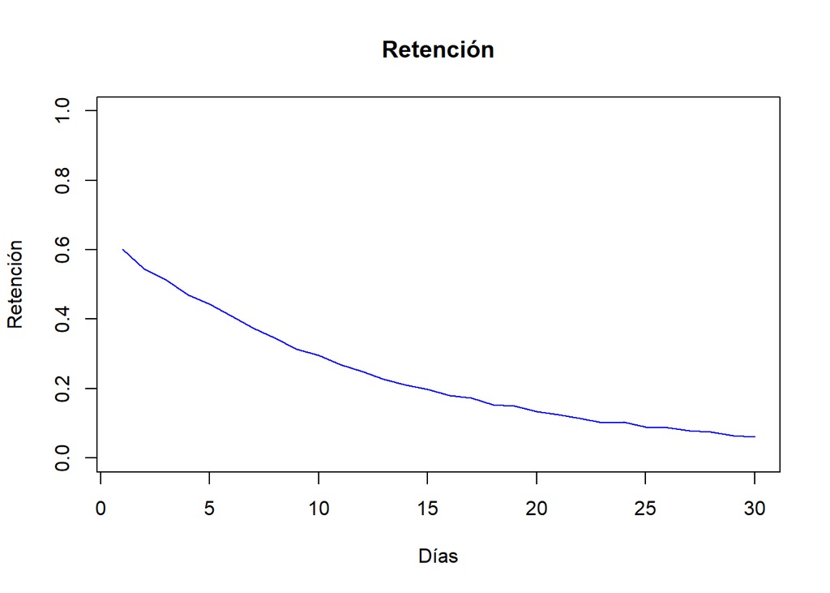

```r
daysToRetention = seq(from=1,to=30,by=1)
Retention = RetentionOfTrackingData(GetTrackinData(), daysToRetention)
plot(daysToRetention,Retention,
     main = "Retención",
     xlab = "Días",
     ylab = "Retención",
     xlim = c(1,30),
     ylim = c(0,1),
     type ="l",
     col = "blue",
     )
```

El gráfico de retención es un tipo de gráfico común en muchos proyectos. Muestra una pendiente que desciende y que acaba estabilizándose con un número pequeño de de jugadores que siguen retenidos. Se destaca que a día 1 ya se ha perdido un 40% de los usuarios.

# 6 Métricas de la Indústria de los Videojuegos

## 6.1 Tiempo de vida (Life Time)

```r
  trackingData = GetTrackinData()
  temp = trackingData[which(trackingData$Action == "Install"),]
  usersDateInstalledTheGame = data.frame(UserID=temp$UserID, DateInstall=temp$Date)

  temp = trackingData[which(trackingData$Action == "Uninstall"),]
  usersDateUninstalledTheGame = data.frame(UserID=temp$UserID, DateUnistall=temp$Date)

  usersDatesLifeTime = merge(usersDateInstalledTheGame,usersDateUninstalledTheGame, all.y=TRUE)

  usersDatesLifeTime = data.frame(usersDatesLifeTime,LifeTime=as_date(as.character(usersDatesLifeTime$DateUnistall)) - as_date(as.character(usersDatesLifeTime$DateInstall)))

  LT_average = mean(usersDatesLifeTime$LifeTime)
```

En el juego del estudio, los usuario tienen un tiempo de vida de media de **11.41 días**.

## 6.2 Ingresos diarios (Daily Revenue)

#### 6.2.0.1 Compute and plot the revenue per day and per month. Also compute the total revenue of the tracking period.

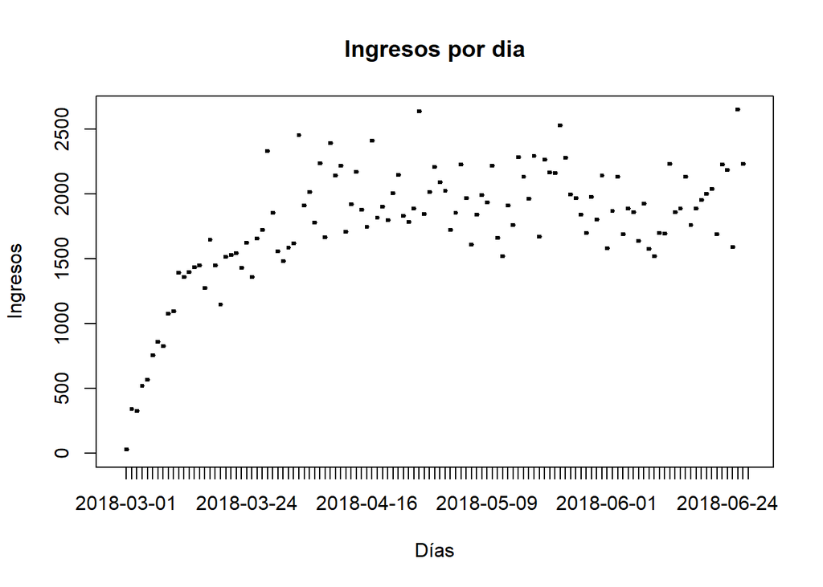

```r
  trackingData = GetTrackinData()
  temp = trackingData[which(trackingData$Action == "Session"),]
  usersDateSessionsMoneySpent = data.frame(UserID=temp$UserID, Date=temp$Date, Money=temp$MoneySpent, DateMonth=month(as.POSIXlt(temp$Date, format="%Y-%m-%d")))

  group_days = summarise(group_by(usersDateSessionsMoneySpent,Date),Revenue=sum(Money))

  plot(group_days,
       main = "Ingresos por dia",
     xlab = "Días",
     ylab = "Ingresos",
     xlim = c(0,120),
     ylim = c(0,max(group_days$Revenue)),
     type ="h",
     col = "blue",
     )
```

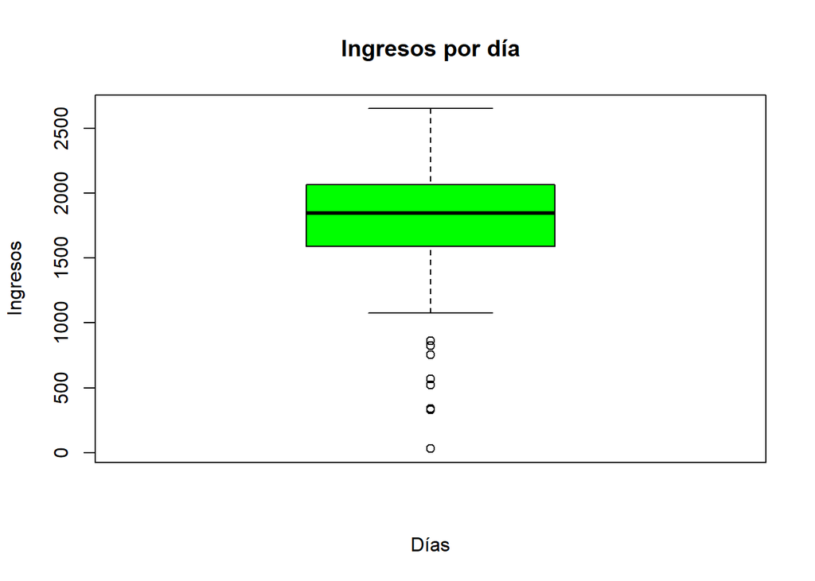

```r
  boxplot(group_days$Revenue,
          main = "Ingresos por día",
          names = c("Días"),
          col = c("Green"),
          ylab = "Ingresos",
          xlab = "Días"
          )
```

De la información que proporcionan los dos gráficos, se puede observar cómo hay un crecimiento de los ingresos por día que coincide con el crecimiento de jugadores, así como el los ingresos medios del día. Generalmente, se ingresa diariamente entre 1500 y 2000 unidades monetarias (se desconoze la moneda).

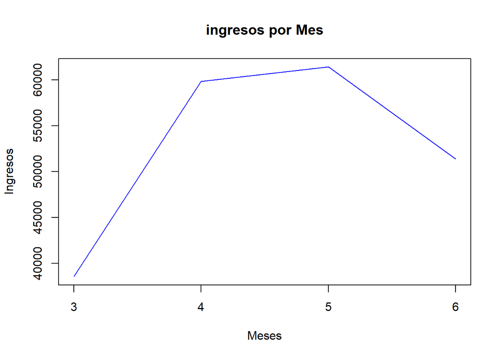

```r
  group_months =summarise(group_by(usersDateSessionsMoneySpent,DateMonth), Revenue=sum(Money))

  plot(group_months,
       main = "ingresos por Mes",
     xlab = "Meses",
     ylab = "Ingresos",
     ylim = c(min(group_months$Revenue),max(group_months$Revenue)),
     type ="l",
     col = "blue",
     xaxt='n',
     )
  axis(side = 1,
       at = c(3,4,5,6),
       labels = c(group_months$DateMonth)
       )
```

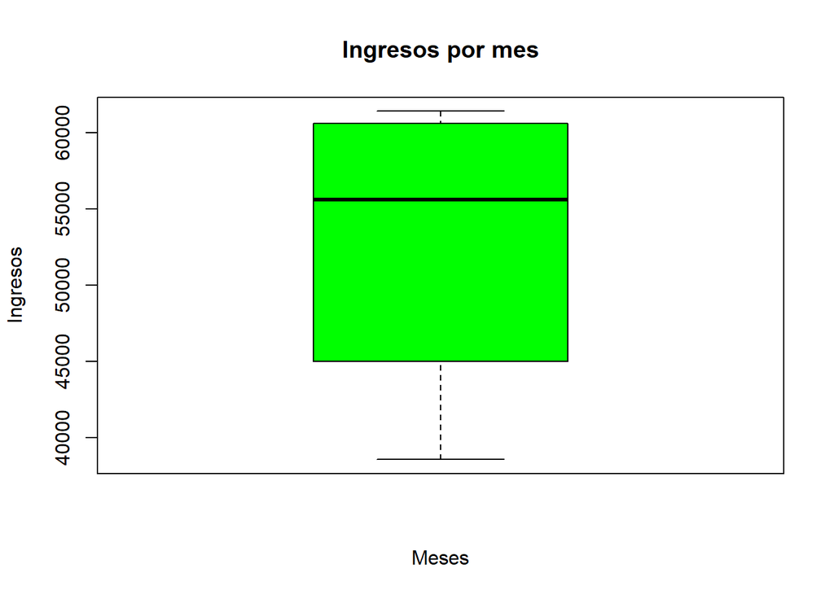

```r
  boxplot(group_months$Revenue,
          main = "Ingresos por mes",
          names = c("Meses"),
          col = c("Green"),
          ylab = "Ingresos",
          xlab = "Meses"
          )
```

Al visualizar los dos gráficos referentes a los ingresos mensuales, se puede ver un subida de ingresos del primer mes al segundo, pero que después decrece del mes 5 al 6. Si se analizan los motivos de este decrecimiento, se descubrirá que el mes 6 no está completo en la muestra de datos. Por lo que este gráfico puede interpretarse de manera incorrecta sin dicha información.

Respecto a la media de ingresos por mes, se detalla que en cada mes se gana entre 45.000 y 60.000 unidades monetarias. Seguramente, el gráfico muestra unos datos con una desviación devido al mes 6.

```r
  revenue = sum(usersDateSessionsMoneySpent$Money)
```

Si se calcula el importe referente a los ingresos generados durante el período de seguimiento, se obtiene un importe de **211248.05 unidades monetarias**.

## 6.3 Ratio de conversión (CR)

```r
  trackingData = GetTrackinData()
  usersData = GetUsersData()
  temp = trackingData[which(trackingData$Action == "Session"),]
  usersMoneySpent = data.frame(UserID=temp$UserID, Money=temp$MoneySpent)
  usersMoneySpent = usersMoneySpent[usersMoneySpent$Money>0,]
  usersMoneySpent = data.frame(summarise(group_by(usersMoneySpent,UserID), Revenue=sum(Money)))

  CR = nrow(usersMoneySpent)/nrow(usersData)
```

El ratio de conversión del juego es del **51.26 %**. Se trata de un ratio muy elevado, ya que significa que más de la mitad de los usuarios han realizado algún pago en el juego. Generalemente es un valor muy inferior al resultado obtenido, aunque puede variar mucho según el tipo de juego y su modelo de ingresos. Se está comparando este ratio con los juegos F2P.

## 6.4 ARPU y ARPPU

```r
  trackingData = GetTrackinData()
  usersData = GetUsersData()
  temp = trackingData[which(trackingData$Action == "Session"),]
  usersMoneySpent = data.frame(UserID=temp$UserID, Money=temp$MoneySpent)
  usersMoneySpent = usersMoneySpent[usersMoneySpent$Money>0,]
  usersMoneySpent = data.frame(summarise(group_by(usersMoneySpent,UserID), Revenue=sum(Money)))

  TotalRevenue = sum(usersMoneySpent$Revenue)
  Users = nrow(data.frame(summarise(group_by(usersData, UserID))))
  PayUsers = nrow(usersMoneySpent)

  ARPU = TotalRevenue/Users
  ARPPU = TotalRevenue/PayUsers
```

Una vez se ha obtenido las métricas de ARPU (**39.52**) y ARPPU (**77.10**), se puede observar cuanto dinero se gastan de manera aproximada o estimada cada usuario (en el caso del ARPU) y cuanto dinero los usuarios que han pagado. Se trata de unos valores que proporcionan información sobre el valor de los usuarios respecto los ingresos totales. De hecho, el ARPPU es más interesante, ya que según esta estimación, los usuarios que pagan, pagarían 77 unidades monetarias.

## 6.5 LTV por usuario

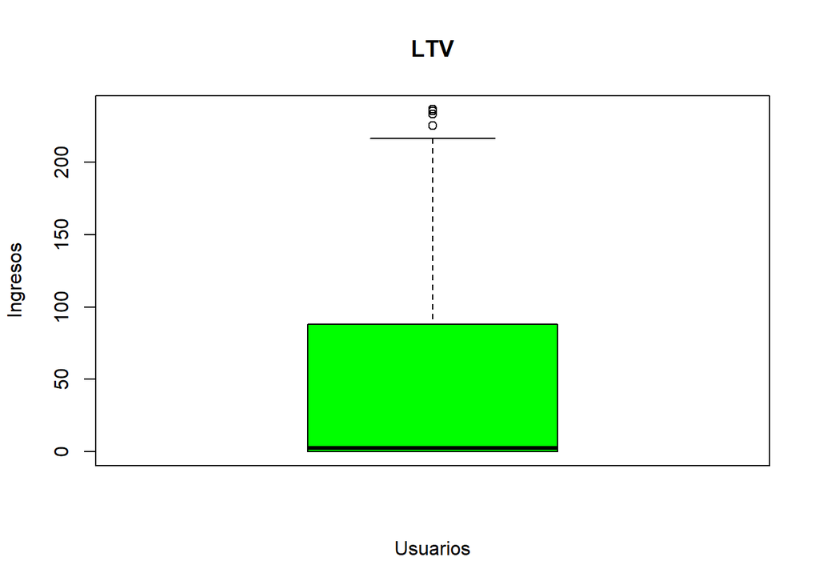

```r
  trackingData = GetTrackinData()
  temp = trackingData[which(trackingData$Action == "Uninstall"),]
  usersChurn = data.frame(UserID=temp$UserID)

  temp = trackingData[which(trackingData$Action == "Session"),]
  usersMoneySpent = data.frame(UserID=temp$UserID, Money=temp$MoneySpent)
  usersMoneySpent = data.frame(summarise(group_by(usersMoneySpent,UserID), Revenue=sum(Money)))

  usersLTV = merge(usersChurn,usersMoneySpent, all.x=TRUE)
  usersLTV[is.na(usersLTV$Revenue),'Revenue'] = 0

  boxplot(usersLTV$Revenue,
          main = "LTV",
          names = c("Usuarios"),
          col = c("Green"),
          ylab = "Ingresos",
          xlab = "Usuarios"
          )
```

La información que se extrae de este boxplot es el rango de ingresos que proporcionan los usuarios durante toda su vida en el juego. Se observa que la gran mayoría realizan muy pocas aportaciones o ninguna, ya que el valor intermedio está muy próximo al mínimo de ingresos.

```r
  LTV = mean(usersLTV$Revenue)
```

De media, la métrica del LTV de este juego es de: **41.81** unidades monetarias.

# 7 Test A/B

## 7.1 Retención

```r
  trackingData = GetTrackinData()
  temp = trackingData[which(trackingData$Action == "Install"),]
  dates = unique(as.character(temp$Date))

  retentionsA= rep(0, length(dates))
  retentionsB = rep(0, length(dates))
  index = 1
  for(date in dates){
      users = data.frame(UserID=as.character(temp[temp$Action == "Install" & as.character(temp$Date) == as.character(date),]$UserID))

      usersA = c(as.character(users[which(grepl("ID1" , users$UserID)),]))
      usersB = c(as.character(users[which(grepl("ID2" , users$UserID)),]))

      resultA = trackingData[which(is.element(as.character(trackingData$UserID), usersA)),]
      resultB = trackingData[which(is.element(as.character(trackingData$UserID), usersB)),]

      retentionsA[index]=RetentionOfTrackingData(resultA, c(14))
      retentionsB[index]=RetentionOfTrackingData(resultB, c(14))

      index=index+1
  }

  #Fix values sin retención
  retentionsA = retentionsA[1:105]
  retentionsB = retentionsB[1:105]
```

### 7.1.1 ¿De qué tipo de inferencia se trata?

Podemos observar que contamos con dos muestras no emparejadas dado que contamos con la versión del juego uno y la dos con distintos tipos de id jugador para cada una.

### 7.1.2 Hipótesis nula y alternativa

**Hº:** Version 1 = Version 2.

**H’:** Version 1 != Version 2.

### 7.1.3 Método apropiado para el estudio

Debido a que nos encontramos con un dataframe que supera por mucho el limite de 30 que marcaria una distribución T-Student, procederemos a calcular con el metodo de distribución Normal. Además contamos con un grafico bilateral.

### 7.1.4 Prueba de hipótesis. ¿Qué tipo de “cola” es?

```r
MeanGroup1 <- mean(retentionsA, na.rm = TRUE)
MeanGroup2 <- mean(retentionsB, na.rm = TRUE)

StandardDeviationGroup1 <- sd(retentionsA, na.rm = TRUE)
StandardDeviationGroup2 <- sd(retentionsB, na.rm = TRUE)

n1 <- length(retentionsA)
n2 <- length(retentionsB)


df <- n1 + n2 - 2

q <- qnorm(0.025, lower.tail = FALSE)

s <- sqrt((((n1-1)*(StandardDeviationGroup1^2))+((n2-1)*(StandardDeviationGroup2^2))))/df

zobs <- (MeanGroup1 - MeanGroup2) / s * sqrt((1/n1) + (1/n2))
```

Debido a que nuestra z observada entra dentro del rango delimitado por los quartiles, podemos decir que, no podemos descartar la hipotesis nula.

### 7.1.5 Calcular el p-value

```r
pnorm1 <- pnorm(zobs, lower.tail = FALSE)
```

Según el p-value podemos asegurar de que no podemos descartar la hipotesis nula con un 48% de seguridad.

### 7.1.6 Interpretar resultados

Como conclusión creemos que, la retención entre las dos versiones es muy similar, por lo que no hay apenas diferencia entre una u otra a la hora de retener a los jugadores.

## 7.2 Tiempo de Juego de los usuarios

### 7.2.1 Escribe las hipotesis nula y alternativa

**Hº:** Version 1 <= Version 2.

**H’:** Version 1 > Version 2.

### 7.2.2 ¿Cual seria el metodo mas preciso de aproximación?

El mejor porceso para aproximarse a esta hipotesis es una distribución normal debido a la gran cantidad de datos que nos aporta el dataframe y tenemos como foco un grafico unilateral por la derecha.

### 7.2.3 Prueba la hipotesis. Justifica que tipo de “cola” tiene.

```r
trackingData = GetTrackinData()

temp = trackingData[which(trackingData$Action == "Session"),]

UsuariosVersion1 <- temp[which(grepl("ID1" , temp$UserID)),]
UsuariosVersion2 <- temp[which(grepl("ID2" , temp$UserID)),]

MG1 <- summarise(group_by(UsuariosVersion1, UserID), mean(SessionLenght))
MG2 <- summarise(group_by(UsuariosVersion2, UserID), mean(SessionLenght))

meanMG1 <- mean(MG1$`mean(SessionLenght)`)
meanMG2 <- mean(MG2$`mean(SessionLenght)`)

SDMG1 <- sd(UsuariosVersion1$SessionLenght)
SDMG2 <- sd(UsuariosVersion2$SessionLenght)


n1.1 <- length(UsuariosVersion1$SessionLenght)
n2.2 <- length(UsuariosVersion2$SessionLenght)

df2 <- (n1.1 + n2.2) - 2

q2 <- qnorm(0.05, lower.tail = FALSE)

s2 <- sqrt((((22207 * 8281) + (22065 * 3600)) / 44270))

zobs2 <- ((93.713) / (s2 * (sqrt(1/n1.1 + 1/n2.2))))
```

### 7.2.4 Computa el p-value.

```r
pnorm2 <- pnorm(zobs2, lower.tail = FALSE)
```

### 7.2.5 Interpreta los resultados.

Podemos observar que rechazamos la hipotesis nula debido a que nuestra z observada se encuentra fuera del rango de nuestro quartil. Por otro lado nuestro p-vale es inferior a alpha por lo que confirmamos el descartar la hipotesis nula y nos quedamos con la alternativa.

# 8 Clustering

```r
  usersData = GetUsersData()
  trackingData = GetTrackinData()

  usersSex  = rep(-1,length(usersData$UserID))
  averagePlayingTimePerSesion = rep(-1,length(usersData$UserID))  # tiempo medio de juego por sesion
  moneySpent = rep(-1,length(usersData$UserID))                   # dinero gastado por cada usuario
  numberOfSesions = rep(-1,length(usersData$UserID))              # sesiones por usuario
  moneyPerSesion = rep(-1,length(usersData$UserID))               # money spent / sesions

  counter = 1
  for (user in usersData$UserID) {

    # Busca todos los eventos relacionados con el usuario en cuestion
    userExtractedData = trackingData[trackingData$UserID == user,]
    userExtractedData = userExtractedData[userExtractedData$Action == "Session",]

    # B) Sexo del usuario ---------------------------------------------------------------------
    # Debido a que el clustering opera con VALORES NUMERICOS convertimos el character en un valor interpretable
    if (usersData[usersData$UserID == user,]$sex == "M")
      usersSex[counter] = -1   # Male
    else
      usersSex[counter] = 1   # Female

    # C) tiempo de juego medio de las sesiones ---------------------------------------------
    sesionsLenght = as.numeric( userExtractedData[userExtractedData$UserID == user,]$SessionLenght )
    averagePlayingTimePerSesion[counter] = mean(sesionsLenght)

    # F) cantidad de sesiones regitaradas del jugador --------------------------------------
    sesionsAmount = length(sesionsLenght)
    numberOfSesions[counter] = sesionsAmount

    # D) Dinero gatado por el usuario ---------------------------------------------------------
    money = sum( userExtractedData[userExtractedData$UserID == user,]$MoneySpent , na.rm = TRUE)
    moneySpent[counter] = money

    # E) Dinero gastado por sesion ------------------------------------------------------------
    moneySpentPerSesion = money / sesionsAmount
    moneyPerSesion[counter] = moneySpentPerSesion

    # Aumentamos el counter que marca el usuario con el cual estamos operando
    counter = counter + 1
  }

  # unifica los datos encontrados en un solo data frame
  usersAglomeratedData = data.frame( as.numeric(usersData$age))
  usersAglomeratedData$Sex = factor(  usersSex)
  usersAglomeratedData$NumberOfSesions = as.numeric(  numberOfSesions)
  usersAglomeratedData$averageSesionTime = averagePlayingTimePerSesion
  usersAglomeratedData$MoneySpent =  moneySpent
  usersAglomeratedData$MoneySpentPerSesion = moneyPerSesion

  # Limpieza y decoracion
  usersAglomeratedData = usersAglomeratedData[usersAglomeratedData$NumberOfSesions != 0,]
  colnames(usersAglomeratedData) = c("Age",
                                     "Sex",
                                     "Nº Sesions",
                                     "Average Session Time",
                                     "Money spent" ,
                                     "Money spent per Session")

  # CLUSTERING ---------------------------------------------------------------------
  CalculateClusteringWIthKmeans = function (inputData,kValue, nStart)
  {
    result <- kmeans(inputData,centers = kValue, nstart = nStart)
    return(result)
  }

  resultKTwo = CalculateClusteringWIthKmeans(usersAglomeratedData,2,50)
  resultKThree = CalculateClusteringWIthKmeans(usersAglomeratedData,3,50)
  resultSeven = CalculateClusteringWIthKmeans(usersAglomeratedData,7,50)
```

El identificador numérico usado en las siguientes explicaciones de cada grupo puede variar dependiendo de la ejecucion de KMeans.

**K = 2**

```r
resultKTwo
```

```
## K-means clustering with 2 clusters of sizes 3681, 1564
##
## Cluster means:
##        Age       Sex Nº Sesions Average Session Time Money spent
## 1 45.29204  0.132301   8.005433             239.3690    7.883024
## 2 37.56330 -1.000000   9.466752             217.4551  116.515756
##   Money spent per Session
## 1                1.476311
## 2               12.716588
##
## Clustering vector:
##    1    2    3    4    5    6    7    8    9   10   11   12   13   14   15   16
##    2    2    1    1    1    1    1    1    2    1    1    2    1    1    2    1
##   17   18   19   20   21   22   23   24   25   26   27   28   29   30   31   32
##    1    1    1    2    1    1    1    1    1    1    2    1    1    1    2    2
```

[output cut: 661 more lines]

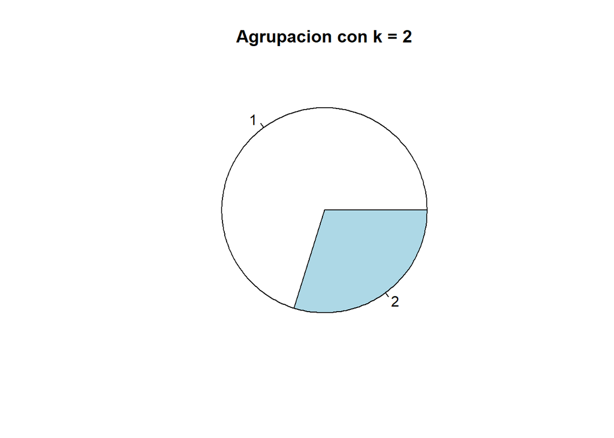

```r
pie (table( resultKTwo$cluster),
     main = "Agrupacion con k = 2")
```

**K = 3**

```r
resultKThree
```

```
## K-means clustering with 3 clusters of sizes 1322, 1966, 1957
##
## Cluster means:
##        Age         Sex Nº Sesions Average Session Time Money spent
## 1 37.50605 -1.00000000   9.786687             218.3585  125.232689
## 2 45.04832  0.09867752   8.628688             185.8985    9.623056
## 3 44.61983  0.02606030   7.343894             289.7654   13.679872
##   Money spent per Session
## 1               13.233048
## 2                1.390648
## 3                2.603444
##
## Clustering vector:
##    1    2    3    4    5    6    7    8    9   10   11   12   13   14   15   16
##    2    1    2    3    2    2    2    3    1    3    3    1    2    3    1    3
```

[output cut: 663 more lines]

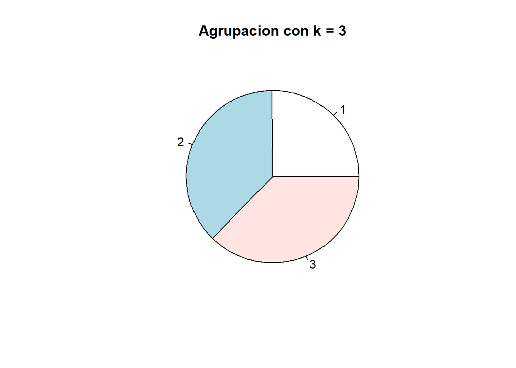

```r
pie (table( resultKThree$cluster),
     main = "Agrupacion con k = 3")
```

En el caso de utilizar k = 3 nos encontramos con que el output esta formado por 3 grupos (como es de esperar).

En cuanto al tiempo de juego encontramos que el claro ganador (en cuanto a cantidad) es el tercer grupo (grupo mixto) ya que tiene la mayor cantidad de horas. Ademas este grupo gasta poco en total y poco por sesion. Tambien es el grupo que menos juega. El segundo grupo juega algo mas aunque sus sesiones son mas cortas que las del grupo 3 y 1. Este grupo ademas gasta menos que el grupo 1 y 3 siendo entonces el qu emenos gasta por sesion y en total. Es el grupo 1, el grupo formado exclusivamente por hombres, el que mas ha gastado por sesion y en total. Esto es curioso ya que puede contradecir el estudio inicial.

**K = 7**

```r
resultSeven
```

```
## K-means clustering with 7 clusters of sizes 249, 418, 1474, 441, 616, 1543, 504
##
## Cluster means:
##        Age         Sex Nº Sesions Average Session Time Money spent
## 1 37.15261 -1.00000000  10.863454             260.4942  167.811132
## 2 37.97608 -1.00000000  10.272727             176.6102  143.955470
## 3 46.26052  0.24694708   8.261872             263.4975    3.953541
## 4 43.65760 -0.06122449   4.544218             351.8091   10.022631
## 5 37.54221 -1.00000000   8.525974             272.3888   88.148940
## 6 45.93778  0.24173688   8.828257             180.3227    3.635271
## 7 37.49008 -1.00000000   8.371032             184.4417   77.645287
##   Money spent per Session
## 1              15.9029276
## 2              14.5278830
## 3               0.8355221
```

[output cut: 671 more lines]

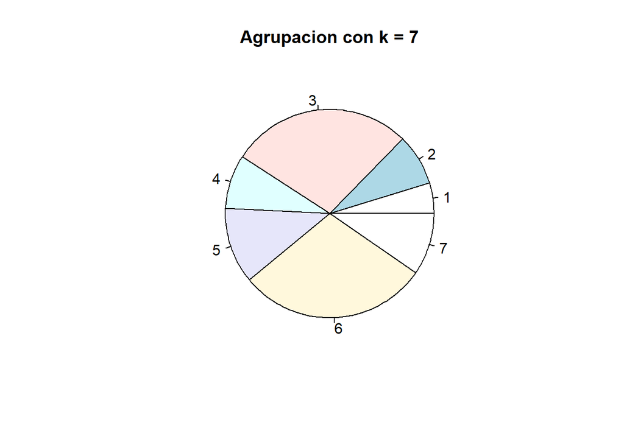

```r
pie (table( resultSeven$cluster),
     main = "Agrupacion con k = 7")
```

**CONCLUSION CLUSTERING**

Tras llevar a cabo varios ejercicios de clustering podemos observar una tendencia bastante pronunciada a la discriminacion de clusters mediante el sexo y sobre el dinero gastado en total y po rsesion. Esto nos indica que existe una disparidad importante en estos atributos (al menos es lo que se interpreta de los clusters que han surgido como resultado) y que son valores clave en la separacion en grupos.

```r
  resultKTwo$centers
```

```
##        Age       Sex Nº Sesions Average Session Time Money spent
## 1 45.29204  0.132301   8.005433             239.3690    7.883024
## 2 37.56330 -1.000000   9.466752             217.4551  116.515756
##   Money spent per Session
## 1                1.476311
## 2               12.716588
```

```r
  resultKThree$centers
```

```
##        Age         Sex Nº Sesions Average Session Time Money spent
## 1 37.50605 -1.00000000   9.786687             218.3585  125.232689
## 2 45.04832  0.09867752   8.628688             185.8985    9.623056
## 3 44.61983  0.02606030   7.343894             289.7654   13.679872
##   Money spent per Session
## 1               13.233048
## 2                1.390648
## 3                2.603444
```

```r
  resultSeven$centers
```

```
##        Age         Sex Nº Sesions Average Session Time Money spent
## 1 37.15261 -1.00000000  10.863454             260.4942  167.811132
## 2 37.97608 -1.00000000  10.272727             176.6102  143.955470
## 3 46.26052  0.24694708   8.261872             263.4975    3.953541
## 4 43.65760 -0.06122449   4.544218             351.8091   10.022631
## 5 37.54221 -1.00000000   8.525974             272.3888   88.148940
## 6 45.93778  0.24173688   8.828257             180.3227    3.635271
## 7 37.49008 -1.00000000   8.371032             184.4417   77.645287
##   Money spent per Session
## 1              15.9029276
## 2              14.5278830
## 3               0.8355221
## 4               2.9704873
## 5              11.2480818
## 6               0.5386479
## 7               9.8989331
```

Si planteamos cada cluster como el individuo “perfecto” de cada agrupacion cuando trabajamos con **2 como valor de k** encontramos que: - Los hombres **gastan mas** que las mujeres , **juegan mas** pero tienen **sesiones mas cortas**. - Los hombres son por lo general **mas jovenes** que las mujeres que juegan a este juego.

Si nos fijamos en la agrupacion con **k=3** - Los hombres **gastan mas** que las mujeres , **juegan mas** pero tienen **sesiones mas cortas**. - Existe un grupo que supera el 30% de tamaño que **no gasta casi dinero** formado por un mix tanto de hombres como de mujeres donde existe una mayor cantidad de mujeres.

Si nos fijamos en la agrupacion con **K = 7** - Los hombres **gastan mas** que las mujeres , **juegan mas** pero tienen **sesiones mas cortas**. - Existe una separacion importante entre **quien gasta mas y quien menos** - Por lo general las **mujeres juegan mas** de forma **mas esporadica**

# 9 Conclusiones

## 9.1 ¿Que tipo de información podemos sacar de los datos? Puedes estructurar tu explicación en diferentes dimensiones del analisis: numero de jugadores, jugabilidad, monetización, etc.

De la información obtenida podemos concluir lo siguiente:

Sobre hypotesis hemos confirmado que la retención de ambas versiones es muy parecida y que el tiempo medio de juego es mayor en la primera version que en la segunda.

## 9.2 ¿Que problemas has encontrado?, en caso de que haya habido alguno, ¿has tenido que investigar más?.

N/A

## 9.3 ¿Que recomendaciones se pueden extraer que puedan resultar utiles a los diseñadores del juego?

Según los datos extraidos nuestra recomendación es la siguiente:

Y no solo enfocarlo a publico masculino sino tambien a un publico mas joven ya que la media de edad del publico masculino es menor.